# Exercise 1 (20 minutes)

When you're done, assist some of the others ...

In Uruguay, the government launched a massive anti-poverty program (PANES). Household eligibility was determined by a Predicted Income Score. If your score was below a specific threshold, you got the money. If you were slightly above, you got nothing. Did receiving this welfare check increase political support for the current government? This question was investigated by Marco Manacorda, Edward Miguel, and Andrea Vigorito. Here you get the original data to replicate their study:

Manacorda, M., Miguel, E., & Vigorito, A. (2011). Government Transfers and Political Support. American Economic Journal: Applied Economics, 3(3), 1–28.

```r
pacman::p_load(
  tidyverse, # Data manipulation,
  ggplot2, # beautiful figures,
  modelsummary, # regression tables
  causaldata, # contains the data
  estimatr) # OLS regression

# Import data used in Manacorda, M., Miguel, E., & Vigorito, A. (2011). Government Transfers and Political Support. American Economic Journal: Applied Economics, 3(3), 1–28.
data("gov_transfers", package = "causaldata")
```

Does there appear to be a jump in support at the cutoff? .

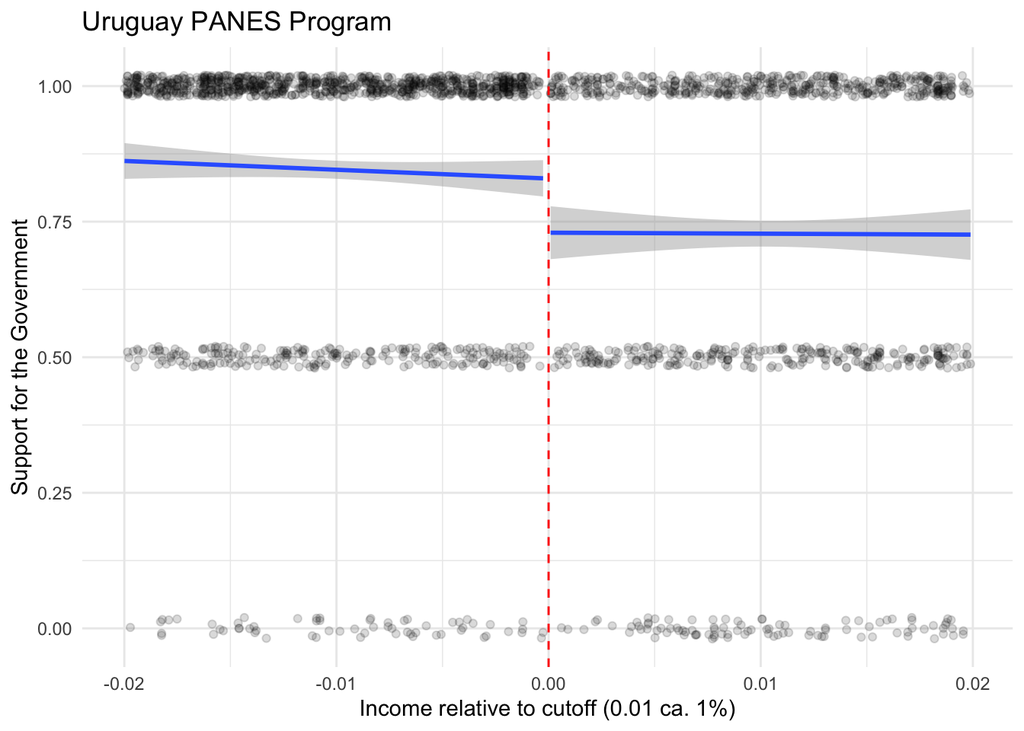

```r
# We create a new logical variable to group the smoothing lines
gov_transfers <- gov_transfers %>%
  mutate(rule = case_when(
    Income_Centered >= 0 ~ "Welfare",
    TRUE ~ "No Welfare"))

ggplot(data = gov_transfers, aes(y = Support, x = Income_Centered)) +
  geom_jitter(alpha = 0.15, height = 0.02, width = 0) +
  geom_vline(xintercept = 0, color = "red", linetype = "dashed") +
  # We use the 'rule' variable to force ggplot to draw two separate lines
  geom_smooth(aes(group = rule), method = "lm") +
  labs(title = "Uruguay PANES Program",
       x = "Income relative to cutoff (0.01 ca. 1%)",
       y = "Support for the Government") +
  theme_minimal()
```

2. Visual inspection is subjective. Let's estimate the size of the jump using a parametric linear regression. Create a dummy variable called `D` that is 1 if `Income_Centered` < 0, and 0 otherwise. Run OLS predicting `Support` using the treatment dummy and the running variable `Income_Centered`. What is the local effect of the welfare program? Is it statistically significant? . What does the estimate tell us had the Government chosen a much higher threshold? .

```r
# 1. Prepare the data
gov_transfers <- gov_transfers %>%
  mutate(
    D = case_when(
    Income_Centered < 0 ~ 1,
    TRUE ~ 0))

# 2. Run the regression
RDD <- lm_robust(Support ~ D*Income_Centered, data = gov_transfers)

modelsummary(list("Support for the Government" = RDD), stars = TRUE,
             gof_map = c("nobs", "r.squared"), output = "gt")
```

|  | Support for the Government |
| --- | --- |
| (Intercept) | 0.730*** |
|  | (0.024) |
| D | 0.100*** |
|  | (0.030) |
| Income_Centered | -0.179 |
|  | (2.046) |
| D × Income_Centered | -1.442 |
|  | (2.500) |
| Num.Obs. | 1948 |
| R2 | 0.034 |

+ p < 0.1, * p < 0.05, ** p < 0.01, *** p < 0.001